# Data Wrangling with R

Author

Kelly Liang

Published

March 17, 2026

**Note**: This codebook is based on the content of the lecture notes published on: [Data Wrangling with Tidyverse](https://jmjung.quarto.pub/m05-1-principles-data-wrangling-with-tidyverse-in-r)

# Overview

## Learning Outcomes

By the end of this module, you will be able to:

- Describe the concept of Data Wrangling.
- Describe how Tibbles are different from data frames
- Explain how to convert wide or long data to “Tidy” data
- Explain how to merge relational data sets using join functions. (Next module)
- Explain how to use grouped mutates and filter together.
- Be familiar with major dplyr functions for transforming data.
- Create a new variable with mutate() and case_when().
- Use the pipe operator to shape the data to prepare for analysis and visualization

**Tip**

To use multi-cursor editing feature, do the following steps: 1. Select the text you want to edit. 2. Press `shift + alt + I` and click on the text you want to edit. 3. You can now edit all the selected text simulatenously.

# Introduction to Data Wrangling

## Loading Packages

**Note**:

- To add a `code chunk`, you can use keyboard shortcut `Ctrl + alt + I` in RStudio.
  - In visual mode: `Ctrl + Alt + I`
  - In source mode: `Ctrl + Shift + I`

```r
if (!require("tidyverse")) install.packages("tidyverse", repos = "https://cran.rstudio.com/")
if (!require("nycflights13")) install.packages("nycflights13", repos = "https://cran.rstudio.com/")
library(tidyverse)
library(nycflights13)
library(dplyr)
```

## Tibbles vs Data Drames

```r
class(mtcars)
```

```
[1] "data.frame"
```

```r
cars.tib <-mtcars |>
    rownames_to_column() |>
    as_tibble() |>
    rename(model = rowname)
cars.tib
```

```
# A tibble: 32 × 12
   model         mpg   cyl  disp    hp  drat    wt  qsec    vs    am  gear  carb
   <chr>       <dbl> <dbl> <dbl> <dbl> <dbl> <dbl> <dbl> <dbl> <dbl> <dbl> <dbl>
 1 Mazda RX4    21       6  160    110  3.9   2.62  16.5     0     1     4     4
 2 Mazda RX4 …  21       6  160    110  3.9   2.88  17.0     0     1     4     4
 3 Datsun 710   22.8     4  108     93  3.85  2.32  18.6     1     1     4     1
 4 Hornet 4 D…  21.4     6  258    110  3.08  3.22  19.4     1     0     3     1
 5 Hornet Spo…  18.7     8  360    175  3.15  3.44  17.0     0     0     3     2
 6 Valiant      18.1     6  225    105  2.76  3.46  20.2     1     0     3     1
 7 Duster 360   14.3     8  360    245  3.21  3.57  15.8     0     0     3     4
 8 Merc 240D    24.4     4  147.    62  3.69  3.19  20       1     0     4     2
 9 Merc 230     22.8     4  141.    95  3.92  3.15  22.9     1     0     4     2
10 Merc 280     19.2     6  168.   123  3.92  3.44  18.3     1     0     4     4
# ℹ 22 more rows
```

```r
class(cars.tib)
```

```
[1] "tbl_df"     "tbl"        "data.frame"
```

```r
typeof(cars.tib)
```

```
[1] "list"
```

## Data Wrangling with dplyr

```r
data()
```

**Data sets in package ‘nycflights13’:**

- airlines – Airline names
- airports – Airport metadata
- flights – Flights data
- planes – Plane metadata
- weather – Hourly weather data

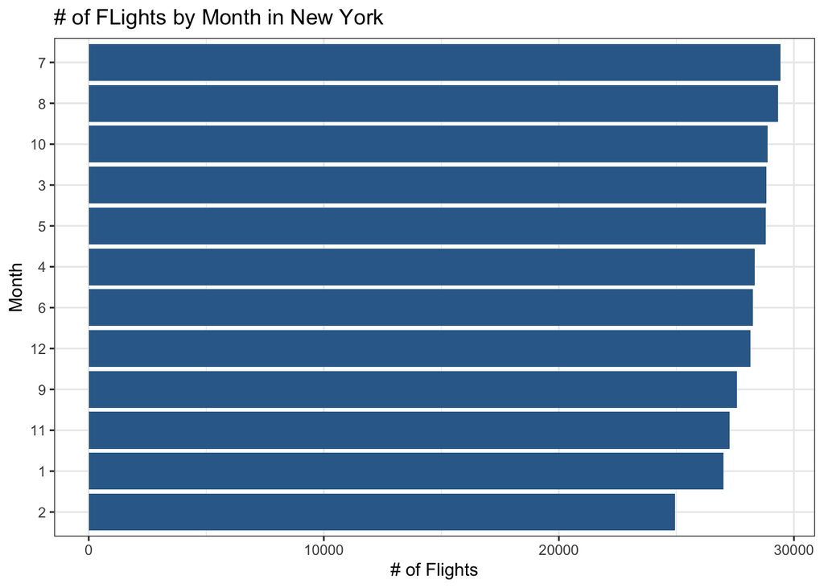

```r
flights_df <- flights

flights_df |>
  dplyr::count(year, month) |>
  arrange(desc(n)) |>
  mutate(month = as_factor(month)) |>
  mutate(month = fct_reorder(month, n)) |>
  ggplot(aes(month, n, fill = year)) +
  geom_col(show.legend = FALSE) +
  coord_flip() +
  labs(
    x = "Month",
    y = "# of Flights",
    title = "# of FLights by Month in New York"
  ) +
  theme_bw()
```